# Risk Factor Analysis

## Outcome Variable

**Outcome Variable:** pers_wasted624

## Predictor Variables

**Intervention Variable:** ever_co06

**Adjustment Set:**

- sex
- arm
- brthmon
- vagbrth
- single
- W_mage
- W_mhtcm
- W_mwtkg
- W_mbmi
- W_meducyrs
- W_feducyrs
- W_parity
- delta_brthmon
- delta_vagbrth
- delta_single
- delta_W_mage
- delta_W_mhtcm
- delta_W_mwtkg
- delta_W_mbmi
- delta_W_meducyrs
- delta_W_feducyrs
- delta_W_parity

## Stratifying Variables

The analysis was stratified on these variable(s):

- studyid
- country

## Data Summary

| studyid | country | ever_co06 | pers_wasted624 | n_cell | n | outcome_variable |
| --- | --- | --- | --- | --- | --- | --- |
| ki0047075b-MAL-ED | BANGLADESH | 0 | 0 | 216 | 240 | pers_wasted624 |
| ki0047075b-MAL-ED | BANGLADESH | 0 | 1 | 15 | 240 | pers_wasted624 |
| ki0047075b-MAL-ED | BANGLADESH | 1 | 0 | 7 | 240 | pers_wasted624 |
| ki0047075b-MAL-ED | BANGLADESH | 1 | 1 | 2 | 240 | pers_wasted624 |
| ki0047075b-MAL-ED | BRAZIL | 0 | 0 | 204 | 207 | pers_wasted624 |
| ki0047075b-MAL-ED | BRAZIL | 0 | 1 | 2 | 207 | pers_wasted624 |
| ki0047075b-MAL-ED | BRAZIL | 1 | 0 | 1 | 207 | pers_wasted624 |
| ki0047075b-MAL-ED | BRAZIL | 1 | 1 | 0 | 207 | pers_wasted624 |
| ki0047075b-MAL-ED | INDIA | 0 | 0 | 196 | 235 | pers_wasted624 |
| ki0047075b-MAL-ED | INDIA | 0 | 1 | 21 | 235 | pers_wasted624 |
| ki0047075b-MAL-ED | INDIA | 1 | 0 | 11 | 235 | pers_wasted624 |
| ki0047075b-MAL-ED | INDIA | 1 | 1 | 7 | 235 | pers_wasted624 |
| ki0047075b-MAL-ED | NEPAL | 0 | 0 | 226 | 235 | pers_wasted624 |
| ki0047075b-MAL-ED | NEPAL | 0 | 1 | 1 | 235 | pers_wasted624 |
| ki0047075b-MAL-ED | NEPAL | 1 | 0 | 7 | 235 | pers_wasted624 |
| ki0047075b-MAL-ED | NEPAL | 1 | 1 | 1 | 235 | pers_wasted624 |
| ki0047075b-MAL-ED | PERU | 0 | 0 | 267 | 270 | pers_wasted624 |
| ki0047075b-MAL-ED | PERU | 0 | 1 | 2 | 270 | pers_wasted624 |
| ki0047075b-MAL-ED | PERU | 1 | 0 | 0 | 270 | pers_wasted624 |
| ki0047075b-MAL-ED | PERU | 1 | 1 | 1 | 270 | pers_wasted624 |
| ki0047075b-MAL-ED | SOUTH AFRICA | 0 | 0 | 252 | 259 | pers_wasted624 |
| ki0047075b-MAL-ED | SOUTH AFRICA | 0 | 1 | 2 | 259 | pers_wasted624 |
| ki0047075b-MAL-ED | SOUTH AFRICA | 1 | 0 | 5 | 259 | pers_wasted624 |
| ki0047075b-MAL-ED | SOUTH AFRICA | 1 | 1 | 0 | 259 | pers_wasted624 |
| ki0047075b-MAL-ED | TANZANIA, UNITED REPUBLIC OF | 0 | 0 | 241 | 245 | pers_wasted624 |
| ki0047075b-MAL-ED | TANZANIA, UNITED REPUBLIC OF | 0 | 1 | 0 | 245 | pers_wasted624 |
| ki0047075b-MAL-ED | TANZANIA, UNITED REPUBLIC OF | 1 | 0 | 4 | 245 | pers_wasted624 |
| ki0047075b-MAL-ED | TANZANIA, UNITED REPUBLIC OF | 1 | 1 | 0 | 245 | pers_wasted624 |
| ki1000108-CMC-V-BCS-2002 | INDIA | 0 | 0 | 317 | 370 | pers_wasted624 |
| ki1000108-CMC-V-BCS-2002 | INDIA | 0 | 1 | 22 | 370 | pers_wasted624 |

[output cut: 90 more lines]

The following strata were considered:

- studyid: ki0047075b-MAL-ED, country: BANGLADESH
- studyid: ki0047075b-MAL-ED, country: BRAZIL
- studyid: ki0047075b-MAL-ED, country: INDIA
- studyid: ki0047075b-MAL-ED, country: NEPAL
- studyid: ki0047075b-MAL-ED, country: PERU
- studyid: ki0047075b-MAL-ED, country: SOUTH AFRICA
- studyid: ki0047075b-MAL-ED, country: TANZANIA, UNITED REPUBLIC OF
- studyid: ki1000108-CMC-V-BCS-2002, country: INDIA
- studyid: ki1000108-IRC, country: INDIA
- studyid: ki1000109-EE, country: PAKISTAN
- studyid: ki1000109-ResPak, country: PAKISTAN
- studyid: ki1000304b-SAS-CompFeed, country: INDIA
- studyid: ki1000304b-SAS-FoodSuppl, country: INDIA
- studyid: ki1017093-NIH-Birth, country: BANGLADESH
- studyid: ki1017093b-PROVIDE, country: BANGLADESH
- studyid: ki1017093c-NIH-Crypto, country: BANGLADESH
- studyid: ki1066203-TanzaniaChild2, country: TANZANIA, UNITED REPUBLIC OF
- studyid: ki1101329-Keneba, country: GAMBIA
- studyid: ki1112895-Guatemala BSC, country: GUATEMALA
- studyid: ki1113344-GMS-Nepal, country: NEPAL
- studyid: ki1114097-CMIN, country: BANGLADESH
- studyid: ki1114097-CONTENT, country: PERU
- studyid: ki1119695-PROBIT, country: BELARUS
- studyid: ki1126311-ZVITAMBO, country: ZIMBABWE
- studyid: ki1135781-COHORTS, country: GUATEMALA
- studyid: ki1135781-COHORTS, country: INDIA
- studyid: ki1135781-COHORTS, country: PHILIPPINES
- studyid: ki1148112-LCNI-5, country: MALAWI
- studyid: kiGH5241-JiVitA-3, country: BANGLADESH
- studyid: kiGH5241-JiVitA-4, country: BANGLADESH

### Dropped Strata

Some strata were dropped due to rare outcomes:

- studyid: ki0047075b-MAL-ED, country: BANGLADESH
- studyid: ki0047075b-MAL-ED, country: BRAZIL
- studyid: ki0047075b-MAL-ED, country: NEPAL
- studyid: ki0047075b-MAL-ED, country: PERU
- studyid: ki0047075b-MAL-ED, country: SOUTH AFRICA
- studyid: ki0047075b-MAL-ED, country: TANZANIA, UNITED REPUBLIC OF
- studyid: ki1112895-Guatemala BSC, country: GUATEMALA
- studyid: ki1114097-CONTENT, country: PERU
- studyid: ki1119695-PROBIT, country: BELARUS
- studyid: ki1148112-LCNI-5, country: MALAWI

## Methods Detail

We’re interested in the causal parameters $E[Y_a]$ for all values of $a \in \mathcal{A}$. These parameters represent the mean outcome if, possibly contrary to fact, we intervened to set all units to have $A=a$. Under the randomization and positivity assumptions, these are identified by the statistical parameters $\psi_a=E_W[E_{Y|A,W}(Y|A=a,W)]$. In addition, we’re interested in the mean of $Y$, $E[Y]$ under no intervention (the observed mean). We will estimate these parameters by using SuperLearner to fit the relevant likelihood factors – $E_{Y|A,W}(Y|A=a,W)$ and $p(A=a|W)$, and then updating our likelihood fit using a joint TMLE.

For unadjusted analyses ($W=\{\}$), initial likelihoods were estimated using Lrnr_glm to estimate the simple $E(Y|A)$ and Lrnr_mean to estimate $p(A)$. For adjusted analyses, a small library containing Lrnr_glmnet, Lrnr_xgboost, and Lrnr_mean was used.

Having estimated these parameters, we will then use the delta method to estimate relative risks and attributable risks relative to a prespecified baseline level of $A$.

# Results Detail

## Results Plots

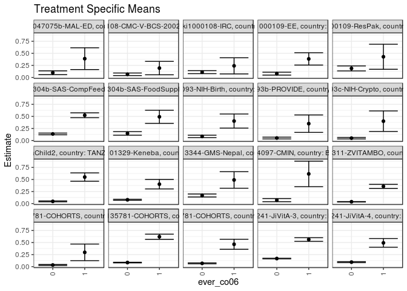

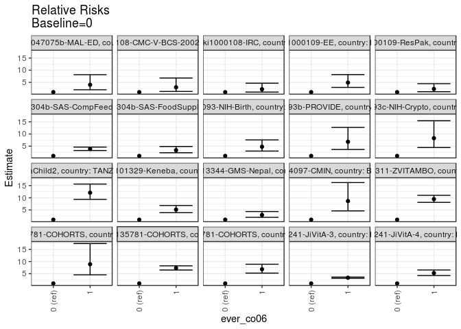

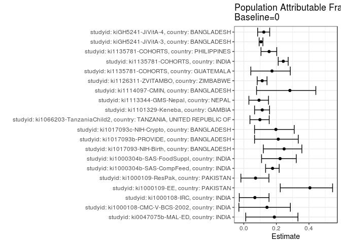

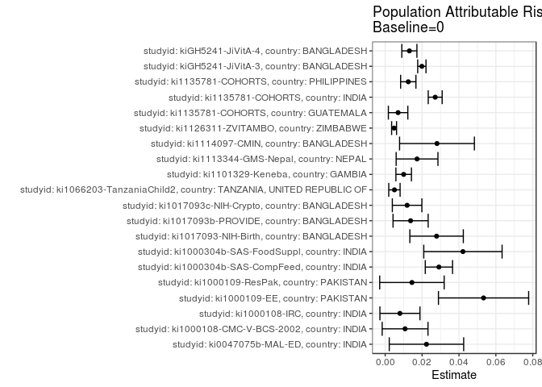

## Results Table

### Parameter: TSM

| studyid | country | intervention_level | baseline_level | estimate | ci_lower | ci_upper |
| --- | --- | --- | --- | --- | --- | --- |
| ki0047075b-MAL-ED | INDIA | 0 | NA | 0.0967742 | 0.0573537 | 0.1361947 |
| ki0047075b-MAL-ED | INDIA | 1 | NA | 0.3888889 | 0.1631997 | 0.6145780 |
| ki1000108-CMC-V-BCS-2002 | INDIA | 0 | NA | 0.0648968 | 0.0386378 | 0.0911557 |
| ki1000108-CMC-V-BCS-2002 | INDIA | 1 | NA | 0.1935484 | 0.0542844 | 0.3328124 |
| ki1000108-IRC | INDIA | 0 | NA | 0.1093750 | 0.0781199 | 0.1406301 |
| ki1000108-IRC | INDIA | 1 | NA | 0.2400000 | 0.0723815 | 0.4076185 |
| ki1000109-EE | PAKISTAN | 0 | NA | 0.0780395 | 0.0480999 | 0.1079790 |
| ki1000109-EE | PAKISTAN | 1 | NA | 0.3841867 | 0.2560531 | 0.5123203 |
| ki1000109-ResPak | PAKISTAN | 0 | NA | 0.1863636 | 0.1347978 | 0.2379295 |
| ki1000109-ResPak | PAKISTAN | 1 | NA | 0.4285714 | 0.1687909 | 0.6883520 |
| ki1000304b-SAS-CompFeed | INDIA | 0 | NA | 0.1357371 | 0.1176044 | 0.1538697 |
| ki1000304b-SAS-CompFeed | INDIA | 1 | NA | 0.5235546 | 0.4734755 | 0.5736336 |
| ki1000304b-SAS-FoodSuppl | INDIA | 0 | NA | 0.1469098 | 0.1097845 | 0.1840352 |
| ki1000304b-SAS-FoodSuppl | INDIA | 1 | NA | 0.4914034 | 0.3548966 | 0.6279102 |
| ki1017093-NIH-Birth | BANGLADESH | 0 | NA | 0.0846867 | 0.0601128 | 0.1092606 |
| ki1017093-NIH-Birth | BANGLADESH | 1 | NA | 0.4032412 | 0.2569262 | 0.5495563 |
| ki1017093b-PROVIDE | BANGLADESH | 0 | NA | 0.0512743 | 0.0334070 | 0.0691416 |
| ki1017093b-PROVIDE | BANGLADESH | 1 | NA | 0.3491228 | 0.1681955 | 0.5300501 |
| ki1017093c-NIH-Crypto | BANGLADESH | 0 | NA | 0.0483989 | 0.0325912 | 0.0642066 |
| ki1017093c-NIH-Crypto | BANGLADESH | 1 | NA | 0.4007096 | 0.1876664 | 0.6137528 |
| ki1066203-TanzaniaChild2 | TANZANIA, UNITED REPUBLIC OF | 0 | NA | 0.0455455 | 0.0362596 | 0.0548315 |
| ki1066203-TanzaniaChild2 | TANZANIA, UNITED REPUBLIC OF | 1 | NA | 0.5500000 | 0.4635436 | 0.6364564 |
| ki1101329-Keneba | GAMBIA | 0 | NA | 0.0783231 | 0.0670733 | 0.0895729 |
| ki1101329-Keneba | GAMBIA | 1 | NA | 0.4021796 | 0.3039373 | 0.5004219 |
| ki1113344-GMS-Nepal | NEPAL | 0 | NA | 0.1674801 | 0.1364203 | 0.1985399 |
| ki1113344-GMS-Nepal | NEPAL | 1 | NA | 0.4897740 | 0.3179682 | 0.6615798 |
| ki1114097-CMIN | BANGLADESH | 0 | NA | 0.0711297 | 0.0384773 | 0.1037821 |
| ki1114097-CMIN | BANGLADESH | 1 | NA | 0.6153846 | 0.3503965 | 0.8803728 |
| ki1126311-ZVITAMBO | ZIMBABWE | 0 | NA | 0.0377764 | 0.0340997 | 0.0414532 |
| ki1126311-ZVITAMBO | ZIMBABWE | 1 | NA | 0.3570327 | 0.3150798 | 0.3989856 |
| ki1135781-COHORTS | GUATEMALA | 0 | NA | 0.0333670 | 0.0221687 | 0.0445654 |
| ki1135781-COHORTS | GUATEMALA | 1 | NA | 0.2962963 | 0.1239753 | 0.4686172 |
| ki1135781-COHORTS | INDIA | 0 | NA | 0.0846804 | 0.0779333 | 0.0914274 |
| ki1135781-COHORTS | INDIA | 1 | NA | 0.6207201 | 0.5672270 | 0.6742131 |
| ki1135781-COHORTS | PHILIPPINES | 0 | NA | 0.0679774 | 0.0585213 | 0.0774335 |
| ki1135781-COHORTS | PHILIPPINES | 1 | NA | 0.4642728 | 0.3601111 | 0.5684345 |
| kiGH5241-JiVitA-3 | BANGLADESH | 0 | NA | 0.1679309 | 0.1615848 | 0.1742771 |
| kiGH5241-JiVitA-3 | BANGLADESH | 1 | NA | 0.5629984 | 0.5250760 | 0.6009208 |
| kiGH5241-JiVitA-4 | BANGLADESH | 0 | NA | 0.0935098 | 0.0832828 | 0.1037368 |
| kiGH5241-JiVitA-4 | BANGLADESH | 1 | NA | 0.4929699 | 0.4032234 | 0.5827163 |

### Parameter: E(Y)

| studyid | country | intervention_level | baseline_level | estimate | ci_lower | ci_upper |
| --- | --- | --- | --- | --- | --- | --- |
| ki0047075b-MAL-ED | INDIA | NA | NA | 0.1191489 | 0.0776405 | 0.1606574 |
| ki1000108-CMC-V-BCS-2002 | INDIA | NA | NA | 0.0756757 | 0.0486905 | 0.1026609 |
| ki1000108-IRC | INDIA | NA | NA | 0.1173594 | 0.0861296 | 0.1485892 |
| ki1000109-EE | PAKISTAN | NA | NA | 0.1313673 | 0.0970401 | 0.1656945 |
| ki1000109-ResPak | PAKISTAN | NA | NA | 0.2008547 | 0.1494120 | 0.2522974 |
| ki1000304b-SAS-CompFeed | INDIA | NA | NA | 0.1648590 | 0.1452632 | 0.1844548 |
| ki1000304b-SAS-FoodSuppl | INDIA | NA | NA | 0.1890547 | 0.1507312 | 0.2273783 |
| ki1017093-NIH-Birth | BANGLADESH | NA | NA | 0.1125461 | 0.0859151 | 0.1391771 |
| ki1017093b-PROVIDE | BANGLADESH | NA | NA | 0.0650407 | 0.0455353 | 0.0845460 |
| ki1017093c-NIH-Crypto | BANGLADESH | NA | NA | 0.0602740 | 0.0429977 | 0.0775502 |
| ki1066203-TanzaniaChild2 | TANZANIA, UNITED REPUBLIC OF | NA | NA | 0.0505451 | 0.0409848 | 0.0601054 |
| ki1101329-Keneba | GAMBIA | NA | NA | 0.0883377 | 0.0767324 | 0.0999430 |
| ki1113344-GMS-Nepal | NEPAL | NA | NA | 0.1847458 | 0.1534039 | 0.2160876 |
| ki1114097-CMIN | BANGLADESH | NA | NA | 0.0992063 | 0.0622241 | 0.1361886 |
| ki1126311-ZVITAMBO | ZIMBABWE | NA | NA | 0.0425909 | 0.0387699 | 0.0464119 |
| ki1135781-COHORTS | GUATEMALA | NA | NA | 0.0403543 | 0.0282479 | 0.0524607 |
| ki1135781-COHORTS | INDIA | NA | NA | 0.1117886 | 0.1043466 | 0.1192306 |
| ki1135781-COHORTS | PHILIPPINES | NA | NA | 0.0804843 | 0.0704205 | 0.0905481 |
| kiGH5241-JiVitA-3 | BANGLADESH | NA | NA | 0.1878008 | 0.1812627 | 0.1943389 |
| kiGH5241-JiVitA-4 | BANGLADESH | NA | NA | 0.1066106 | 0.0960765 | 0.1171447 |

### Parameter: RR

| studyid | country | intervention_level | baseline_level | estimate | ci_lower | ci_upper |
| --- | --- | --- | --- | --- | --- | --- |
| ki0047075b-MAL-ED | INDIA | 0 | 0 | 1.000000 | 1.000000 | 1.000000 |
| ki0047075b-MAL-ED | INDIA | 1 | 0 | 4.018518 | 1.977591 | 8.165737 |
| ki1000108-CMC-V-BCS-2002 | INDIA | 0 | 0 | 1.000000 | 1.000000 | 1.000000 |
| ki1000108-CMC-V-BCS-2002 | INDIA | 1 | 0 | 2.982405 | 1.306343 | 6.808882 |
| ki1000108-IRC | INDIA | 0 | 0 | 1.000000 | 1.000000 | 1.000000 |
| ki1000108-IRC | INDIA | 1 | 0 | 2.194286 | 1.031740 | 4.666768 |
| ki1000109-EE | PAKISTAN | 0 | 0 | 1.000000 | 1.000000 | 1.000000 |
| ki1000109-EE | PAKISTAN | 1 | 0 | 4.922979 | 2.956710 | 8.196854 |
| ki1000109-ResPak | PAKISTAN | 0 | 0 | 1.000000 | 1.000000 | 1.000000 |
| ki1000109-ResPak | PAKISTAN | 1 | 0 | 2.299652 | 1.181089 | 4.477561 |
| ki1000304b-SAS-CompFeed | INDIA | 0 | 0 | 1.000000 | 1.000000 | 1.000000 |
| ki1000304b-SAS-CompFeed | INDIA | 1 | 0 | 3.857123 | 3.217396 | 4.624049 |
| ki1000304b-SAS-FoodSuppl | INDIA | 0 | 0 | 1.000000 | 1.000000 | 1.000000 |
| ki1000304b-SAS-FoodSuppl | INDIA | 1 | 0 | 3.344932 | 2.298090 | 4.868639 |
| ki1017093-NIH-Birth | BANGLADESH | 0 | 0 | 1.000000 | 1.000000 | 1.000000 |
| ki1017093-NIH-Birth | BANGLADESH | 1 | 0 | 4.761566 | 2.993269 | 7.574500 |
| ki1017093b-PROVIDE | BANGLADESH | 0 | 0 | 1.000000 | 1.000000 | 1.000000 |
| ki1017093b-PROVIDE | BANGLADESH | 1 | 0 | 6.808923 | 3.646469 | 12.714061 |
| ki1017093c-NIH-Crypto | BANGLADESH | 0 | 0 | 1.000000 | 1.000000 | 1.000000 |
| ki1017093c-NIH-Crypto | BANGLADESH | 1 | 0 | 8.279309 | 4.438032 | 15.445350 |
| ki1066203-TanzaniaChild2 | TANZANIA, UNITED REPUBLIC OF | 0 | 0 | 1.000000 | 1.000000 | 1.000000 |
| ki1066203-TanzaniaChild2 | TANZANIA, UNITED REPUBLIC OF | 1 | 0 | 12.075824 | 9.334896 | 15.621547 |
| ki1101329-Keneba | GAMBIA | 0 | 0 | 1.000000 | 1.000000 | 1.000000 |
| ki1101329-Keneba | GAMBIA | 1 | 0 | 5.134877 | 3.868862 | 6.815174 |
| ki1113344-GMS-Nepal | NEPAL | 0 | 0 | 1.000000 | 1.000000 | 1.000000 |
| ki1113344-GMS-Nepal | NEPAL | 1 | 0 | 2.924372 | 1.967002 | 4.347708 |
| ki1114097-CMIN | BANGLADESH | 0 | 0 | 1.000000 | 1.000000 | 1.000000 |
| ki1114097-CMIN | BANGLADESH | 1 | 0 | 8.651584 | 4.610498 | 16.234669 |
| ki1126311-ZVITAMBO | ZIMBABWE | 0 | 0 | 1.000000 | 1.000000 | 1.000000 |
| ki1126311-ZVITAMBO | ZIMBABWE | 1 | 0 | 9.451198 | 8.114997 | 11.007416 |
| ki1135781-COHORTS | GUATEMALA | 0 | 0 | 1.000000 | 1.000000 | 1.000000 |
| ki1135781-COHORTS | GUATEMALA | 1 | 0 | 8.879910 | 4.537246 | 17.379001 |
| ki1135781-COHORTS | INDIA | 0 | 0 | 1.000000 | 1.000000 | 1.000000 |
| ki1135781-COHORTS | INDIA | 1 | 0 | 7.330152 | 6.520067 | 8.240887 |
| ki1135781-COHORTS | PHILIPPINES | 0 | 0 | 1.000000 | 1.000000 | 1.000000 |
| ki1135781-COHORTS | PHILIPPINES | 1 | 0 | 6.829811 | 5.247859 | 8.888640 |
| kiGH5241-JiVitA-3 | BANGLADESH | 0 | 0 | 1.000000 | 1.000000 | 1.000000 |
| kiGH5241-JiVitA-3 | BANGLADESH | 1 | 0 | 3.352559 | 3.106719 | 3.617854 |
| kiGH5241-JiVitA-4 | BANGLADESH | 0 | 0 | 1.000000 | 1.000000 | 1.000000 |
| kiGH5241-JiVitA-4 | BANGLADESH | 1 | 0 | 5.271852 | 4.260121 | 6.523858 |

### Parameter: PAR

| studyid | country | intervention_level | baseline_level | estimate | ci_lower | ci_upper |
| --- | --- | --- | --- | --- | --- | --- |
| ki0047075b-MAL-ED | INDIA | 0 | NA | 0.0223747 | 0.0021997 | 0.0425498 |
| ki1000108-CMC-V-BCS-2002 | INDIA | 0 | NA | 0.0107789 | -0.0016393 | 0.0231971 |
| ki1000108-IRC | INDIA | 0 | NA | 0.0079844 | -0.0028711 | 0.0188399 |
| ki1000109-EE | PAKISTAN | 0 | NA | 0.0533278 | 0.0288721 | 0.0777836 |
| ki1000109-ResPak | PAKISTAN | 0 | NA | 0.0144911 | -0.0029872 | 0.0319693 |
| ki1000304b-SAS-CompFeed | INDIA | 0 | NA | 0.0291219 | 0.0217294 | 0.0365145 |
| ki1000304b-SAS-FoodSuppl | INDIA | 0 | NA | 0.0421449 | 0.0209143 | 0.0633755 |
| ki1017093-NIH-Birth | BANGLADESH | 0 | NA | 0.0278594 | 0.0133636 | 0.0423553 |
| ki1017093b-PROVIDE | BANGLADESH | 0 | NA | 0.0137664 | 0.0042468 | 0.0232859 |
| ki1017093c-NIH-Crypto | BANGLADESH | 0 | NA | 0.0118751 | 0.0038684 | 0.0198817 |
| ki1066203-TanzaniaChild2 | TANZANIA, UNITED REPUBLIC OF | 0 | NA | 0.0049995 | 0.0019204 | 0.0080787 |
| ki1101329-Keneba | GAMBIA | 0 | NA | 0.0100146 | 0.0058026 | 0.0142266 |
| ki1113344-GMS-Nepal | NEPAL | 0 | NA | 0.0172657 | 0.0059334 | 0.0285979 |
| ki1114097-CMIN | BANGLADESH | 0 | NA | 0.0280766 | 0.0077909 | 0.0483623 |
| ki1126311-ZVITAMBO | ZIMBABWE | 0 | NA | 0.0048144 | 0.0034818 | 0.0061471 |
| ki1135781-COHORTS | GUATEMALA | 0 | NA | 0.0069873 | 0.0017121 | 0.0122625 |
| ki1135781-COHORTS | INDIA | 0 | NA | 0.0271082 | 0.0233329 | 0.0308836 |
| ki1135781-COHORTS | PHILIPPINES | 0 | NA | 0.0125069 | 0.0083605 | 0.0166533 |
| kiGH5241-JiVitA-3 | BANGLADESH | 0 | NA | 0.0198699 | 0.0176251 | 0.0221146 |
| kiGH5241-JiVitA-4 | BANGLADESH | 0 | NA | 0.0131008 | 0.0090128 | 0.0171888 |

### Parameter: PAF

| studyid | country | intervention_level | baseline_level | estimate | ci_lower | ci_upper |
| --- | --- | --- | --- | --- | --- | --- |
| ki0047075b-MAL-ED | INDIA | 0 | NA | 0.1877880 | 0.0119633 | 0.3323241 |
| ki1000108-CMC-V-BCS-2002 | INDIA | 0 | NA | 0.1424357 | -0.0300892 | 0.2860653 |
| ki1000108-IRC | INDIA | 0 | NA | 0.0680339 | -0.0277289 | 0.1548735 |
| ki1000109-EE | PAKISTAN | 0 | NA | 0.4059443 | 0.2239371 | 0.5452661 |
| ki1000109-ResPak | PAKISTAN | 0 | NA | 0.0721470 | -0.0179275 | 0.1542510 |
| ki1000304b-SAS-CompFeed | INDIA | 0 | NA | 0.1766475 | 0.1338890 | 0.2172951 |
| ki1000304b-SAS-FoodSuppl | INDIA | 0 | NA | 0.2229244 | 0.1091279 | 0.3221849 |
| ki1017093-NIH-Birth | BANGLADESH | 0 | NA | 0.2475380 | 0.1201244 | 0.3565011 |
| ki1017093b-PROVIDE | BANGLADESH | 0 | NA | 0.2116577 | 0.0660474 | 0.3345662 |
| ki1017093c-NIH-Crypto | BANGLADESH | 0 | NA | 0.1970179 | 0.0660298 | 0.3096351 |
| ki1066203-TanzaniaChild2 | TANZANIA, UNITED REPUBLIC OF | 0 | NA | 0.0989126 | 0.0378212 | 0.1561252 |
| ki1101329-Keneba | GAMBIA | 0 | NA | 0.1133668 | 0.0661126 | 0.1582301 |
| ki1113344-GMS-Nepal | NEPAL | 0 | NA | 0.0934565 | 0.0313009 | 0.1516239 |
| ki1114097-CMIN | BANGLADESH | 0 | NA | 0.2830126 | 0.0782623 | 0.4422806 |
| ki1126311-ZVITAMBO | ZIMBABWE | 0 | NA | 0.1130387 | 0.0824596 | 0.1425987 |
| ki1135781-COHORTS | GUATEMALA | 0 | NA | 0.1731485 | 0.0431505 | 0.2854850 |
| ki1135781-COHORTS | INDIA | 0 | NA | 0.2424955 | 0.2113223 | 0.2724366 |
| ki1135781-COHORTS | PHILIPPINES | 0 | NA | 0.1553959 | 0.1056689 | 0.2023579 |
| kiGH5241-JiVitA-3 | BANGLADESH | 0 | NA | 0.1058028 | 0.0941559 | 0.1173000 |
| kiGH5241-JiVitA-4 | BANGLADESH | 0 | NA | 0.1228848 | 0.0851053 | 0.1591042 |